# Exploratory Data Analysis of the Instagram Reach Dataset

Sotiris Kylintireas — 3220098

2026-03-17

## 1 Εισαγωγή

Στην παρούσα εργασία πραγματοποιείται διερευνητική ανάλυση δεδομένων (*Exploratory Data Analysis - EDA*) στο dataset *Instagram Reach*, με στόχο να αποτυπωθούν τόσο τα βασικά χαρακτηριστικά των μεταβλητών όσο και οι μεταξύ τους σχέσεις.

Η προσέγγιση ακολουθεί μια σαφή ροή: αρχικά έλεγχος και προεπεξεργασία των δεδομένων, στη συνέχεια δημιουργία νέων κατηγορικών μεταβλητών και υπολογισμός περιγραφικών μέτρων, και τέλος οπτική διερεύνηση με κατάλληλα διαγράμματα.

Παράλληλα, εξετάζεται κατά πόσο βασικές μεταβλητές, όπως ο αριθμός των `Followers` και ο χρόνος από τη δημοσίευση (`Hours.since.posted`), μπορούν να υποστηρίξουν την πρόβλεψη υψηλής αλληλεπίδρασης (*high engagement*) μέσω λογιστικής παλινδρόμησης.

## 2 Executive Summary

This report presents an Exploratory Data Analysis (EDA) of the **Instagram Reach** dataset, which contains **100 posts** and **6 cleaned variables**. The analysis combines descriptive statistics, visual exploration, and predictive modeling.

**Key findings:**

- `Followers` is strongly right-skewed and departs from normality because a limited number of accounts have very high follower counts.
- A moderate positive correlation (r ≈ 0.61) appears between `Hours.since.posted` and `Likes`, indicating that older posts tend to accumulate more engagement.
- Posts in the highest `time` category are more likely to appear in the high-like group.
- A logistic regression model using `Followers` and `Hours.since.posted` achieves approximately **83%** accuracy, with `Hours.since.posted` as the most statistically robust predictor.

## 3 Άσκηση 1: Έλεγχος μεταβλητών

```r
# Place instagram_reach.txt in your R working directory before knitting
instagram_reach <- read.table(
  "instagram_reach.txt",
  header = TRUE,
  stringsAsFactors = FALSE
)
```

Αρχικά ελέγχουμε τη δομή και τις διαστάσεις του dataset.

```r
str(instagram_reach)
```

```
## 'data.frame':    100 obs. of  7 variables:
##  $ S.No              : int  1 2 3 4 5 6 7 8 9 10 ...
##  $ USERNAME          : chr  "mikequindazzi" "drgorillapaints" "aitrading_official" "opensourcedworkplace" ...
##  $ Caption           : chr  "Who are #DataScientist and what do they do? >> @MikeQuindazzi >> #MachineLearning #AI #DataAnalytics #DataScien"| __truncated__ "We all know where it’s going. We just have to #workresponsibly to postpone the date. This actually made into a "| __truncated__ "Alexander …
##  $ Followers         : int  1600 880 255 340 304 1231 259 1433 13 450 ...
##  $ Hashtags          : chr  "#MachineLearning #AI #DataAnalytics #DataScienc #DataLake" " #deck .#mac #macintosh#sayhello #apple #stevejobs #ai #evolution#artificialintelligence #machinelearning#termi"| __truncated__ "#whoiswho #aitrading #ai #aitradingteam#instateam #instapeople #ai #trading#art…
##  $ Hours.since.posted: int  11 2 2 3 3 3 3 4 4 7 ...
##  $ Likes             : int  139 23 25 49 30 18 35 86 22 18 ...
```

```r
dim(instagram_reach)
```

```
## [1] 100   7
```

Αφαιρούμε την πρώτη στήλη (`S.No`), καθώς δεν είναι χρήσιμη.

```r
instagram_reach <- instagram_reach[, -1]
dim(instagram_reach)
```

```
## [1] 100   6
```

Στη συνέχεια, ορίζουμε τον κατάλληλο τύπο για τις μεταβλητές όπου χρειάζεται.

```r
instagram_reach$USERNAME <- as.factor(instagram_reach$USERNAME)
instagram_reach$Caption <- as.character(instagram_reach$Caption)
instagram_reach$Hashtags <- as.character(instagram_reach$Hashtags)
```

Το αρχικό dataset περιείχε 100 παρατηρήσεις και 7 μεταβλητές. Η μεταβλητή `S.No` αφαιρέθηκε, καθώς λειτουργεί μόνο ως αριθμός εγγραφής και δεν προσφέρει χρήσιμη πληροφορία για την ανάλυση. Το τελικό dataset περιλαμβάνει 100 παρατηρήσεις και 6 μεταβλητές. Με αυτή τη δομή, τα δεδομένα είναι πλέον κατάλληλα για τις επόμενες φάσεις ανάλυσης και μοντελοποίησης.

## 4 Άσκηση 2: Δημιουργία νέων μεταβλητών

### 4.1 Δημιουργία μεταβλητής time

```r
instagram_reach$time <- ifelse(instagram_reach$Hours.since.posted == 2, 2,
                        ifelse(instagram_reach$Hours.since.posted == 3, 3, 4))
instagram_reach$time <- as.factor(instagram_reach$time)
```

Έλεγχος μεταβλητής:

```r
time_table <- as.data.frame(table(instagram_reach$time))
kable(time_table,
      col.names = c("time", "Συχνότητα"),
      caption = "Κατανομή της μεταβλητής time") %>%
  kable_styling(full_width = FALSE, position = "center")
```

Κατανομή της μεταβλητής time

| time | Συχνότητα |
| --- | --- |
| 2 | 57 |
| 3 | 19 |
| 4 | 24 |

Η μεταβλητή `time` συνοψίζει τον χρόνο από τη δημοσίευση σε τρεις διακριτές κατηγορίες, ώστε η ερμηνεία να είναι πιο άμεση στις συγκρίσεις που ακολουθούν.

### 4.2 Δημιουργία μεταβλητής like

```r
Q1 <- quantile(instagram_reach$Likes, 0.25)
Q3 <- quantile(instagram_reach$Likes, 0.75)

instagram_reach$like <- ifelse(instagram_reach$Likes < Q1, 1,
                        ifelse(instagram_reach$Likes <= Q3, 2, 3))
instagram_reach$like <- as.factor(instagram_reach$like)
```

Έλεγχος μεταβλητής:

```r
like_table <- as.data.frame(table(instagram_reach$like))
kable(like_table,
      col.names = c("like", "Συχνότητα"),
      caption = "Κατανομή της μεταβλητής like") %>%
  kable_styling(full_width = FALSE, position = "center")
```

Κατανομή της μεταβλητής like

| like | Συχνότητα |
| --- | --- |
| 1 | 24 |
| 2 | 53 |
| 3 | 23 |

```r
quartiles_table <- data.frame(Q1 = as.numeric(Q1), Q3 = as.numeric(Q3))
kable(quartiles_table,
      digits = 2,
      caption = "Τεταρτημόρια της μεταβλητής Likes") %>%
  kable_styling(full_width = FALSE, position = "center")
```

Τεταρτημόρια της μεταβλητής Likes

| Q1 | Q3 |
| --- | --- |
| 19 | 46 |

Η κατηγοριοποίηση της `Likes` με βάση τα τεταρτημόρια επιτρέπει μια σταθερή και διαφανή διάκριση των αναρτήσεων σε χαμηλή, μεσαία και υψηλή αλληλεπίδραση.

## 5 Άσκηση 3: Ποσοτικές μεταβλητές και περιγραφικά μέτρα

```r
numeric_data <- instagram_reach[, c("Followers", "Hours.since.posted", "Likes")]
```

```r
desc_table <- data.frame(
  Variable = names(numeric_data),
  Mean     = sapply(numeric_data, mean),
  SD       = sapply(numeric_data, sd),
  Variance = sapply(numeric_data, var),
  Min      = sapply(numeric_data, min),
  Median   = sapply(numeric_data, median),
  Max      = sapply(numeric_data, max)
)

kable(desc_table,
      digits = 2,
      format.args = list(big.mark = ","),
      caption = "Descriptive Statistics — Numeric Variables",
      col.names = c("Variable", "Mean", "Std. Dev.", "Variance", "Min", "Median", "Max")) %>%
  kable_styling(full_width = FALSE, position = "center") %>%
  row_spec(0, bold = TRUE)
```

Descriptive Statistics — Numeric Variables

|  | Variable | Mean | Std. Dev. | Variance | Min | Median | Max |
| --- | --- | --- | --- | --- | --- | --- | --- |
| Followers | Followers | 961.96 | 1,014.63 | 1,029,465.25 | 11 | 612 | 4,496 |
| Hours.since.posted | Hours.since.posted | 3.46 | 3.39 | 11.52 | 2 | 2 | 24 |
| Likes | Likes | 46.48 | 55.09 | 3,034.58 | 8 | 29 | 349 |

Τα περιγραφικά μέτρα δείχνουν ότι οι μεταβλητές δεν έχουν ομοιόμορφη συμπεριφορά: ειδικά η `Followers` εμφανίζει μεγαλύτερη διασπορά, γεγονός που επηρεάζει τόσο την οπτική ανάλυση όσο και την ερμηνεία των συσχετίσεων.

## 6 Άσκηση 4: Γραφική μελέτη της μεταβλητής Followers

```r
# All report visualizations are implemented with ggplot2 + theme_report().
```

### 6.1 Ιστόγραμμα με καμπύλη πυκνότητας

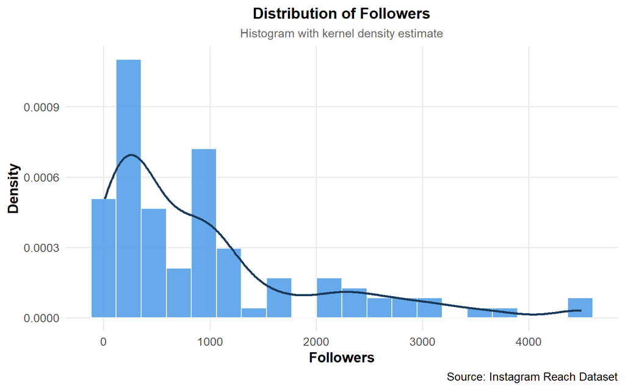

```r
ggplot(instagram_reach, aes(x = Followers)) +
  geom_histogram(aes(y = after_stat(density)), bins = 20,
                 fill = "#4C9BE8", color = "white", alpha = 0.85) +
  geom_density(color = "#1A3A5C", linewidth = 1) +
  labs(title = "Distribution of Followers",
       subtitle = "Histogram with kernel density estimate",
       x = "Followers", y = "Density",
       caption = "Source: Instagram Reach Dataset") +
  theme_report()
```

### 6.2 Θηκόγραμμα

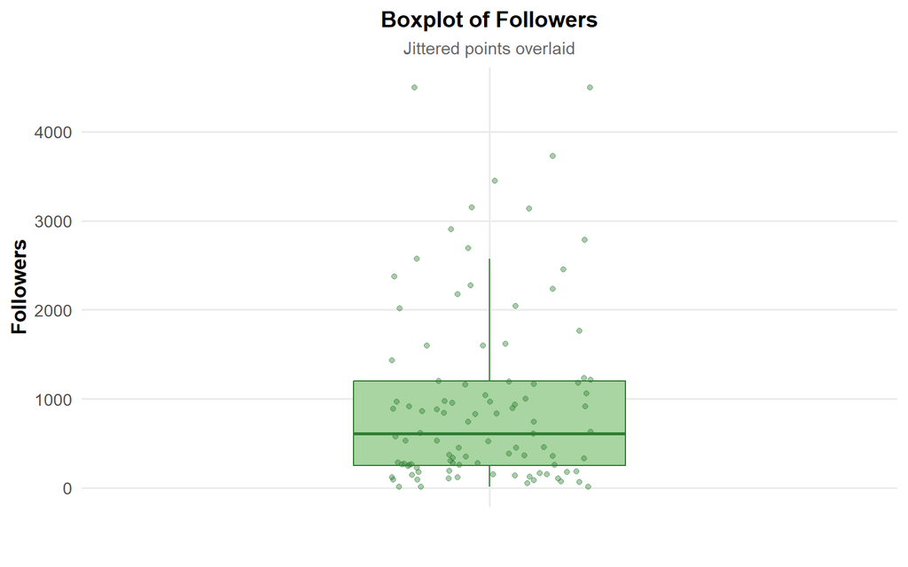

```r
ggplot(instagram_reach, aes(x = "", y = Followers)) +
  geom_boxplot(fill = "#A8D5A2", color = "#2E7D32", width = 0.4, outlier.shape = NA) +
  geom_jitter(width = 0.15, alpha = 0.4, color = "#2E7D32") +
  labs(title = "Boxplot of Followers",
       subtitle = "Jittered points overlaid",
       x = "", y = "Followers") +
  theme_report()
```

### 6.3 QQ Plot

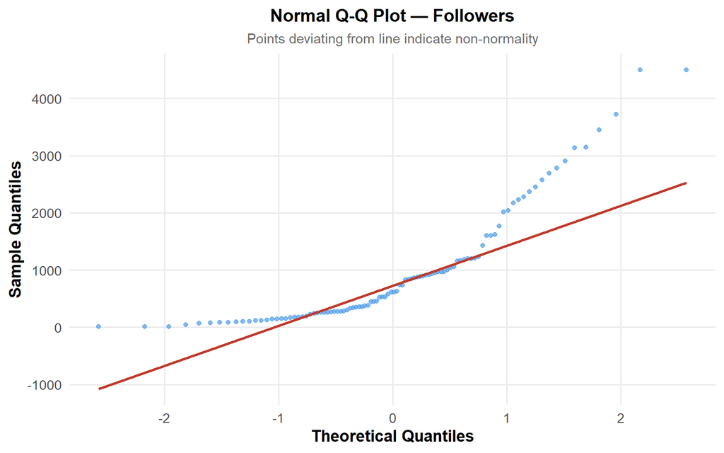

```r
ggplot(instagram_reach, aes(sample = Followers)) +
  stat_qq(color = "#4C9BE8", alpha = 0.7) +
  stat_qq_line(color = "#C0392B", linewidth = 1) +
  labs(title = "Normal Q-Q Plot — Followers",
       subtitle = "Points deviating from line indicate non-normality",
       x = "Theoretical Quantiles", y = "Sample Quantiles") +
  theme_report()
```

## 7 Άσκηση 5: Συχνότητες και γραφήματα για τη μεταβλητή time

```r
freq_time <- table(instagram_reach$time)
rel_freq_time <- prop.table(freq_time)

freq_time_df <- as.data.frame(freq_time)
rel_freq_time_df <- data.frame(
  time = names(rel_freq_time),
  Σχετική_Συχνότητα = as.numeric(rel_freq_time)
)

kable(freq_time_df,
      col.names = c("time", "Συχνότητα"),
      caption = "Πίνακας συχνοτήτων της μεταβλητής time") %>%
  kable_styling(full_width = FALSE, position = "center")
```

Πίνακας συχνοτήτων της μεταβλητής time

| time | Συχνότητα |
| --- | --- |
| 2 | 57 |
| 3 | 19 |
| 4 | 24 |

```r
kable(rel_freq_time_df,
      digits = 2,
      caption = "Πίνακας σχετικών συχνοτήτων της μεταβλητής time") %>%
  kable_styling(full_width = FALSE, position = "center")
```

Πίνακας σχετικών συχνοτήτων της μεταβλητής time

| time | Σχετική_Συχνότητα |
| --- | --- |
| 2 | 0.57 |
| 3 | 0.19 |
| 4 | 0.24 |

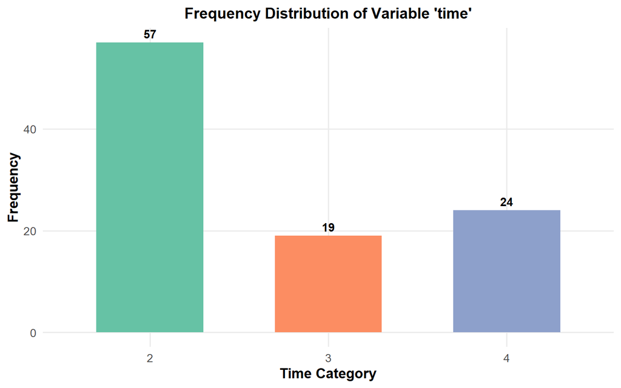

```r
freq_time_df_gg <- as.data.frame(table(instagram_reach$time))
colnames(freq_time_df_gg) <- c("time", "count")

ggplot(freq_time_df_gg, aes(x = time, y = count, fill = time)) +
  geom_col(width = 0.6, show.legend = FALSE) +
  scale_fill_brewer(palette = "Set2") +
  geom_text(aes(label = count), vjust = -0.5, fontface = "bold") +
  labs(title = "Frequency Distribution of Variable 'time'",
       x = "Time Category", y = "Frequency") +
  theme_report()
```

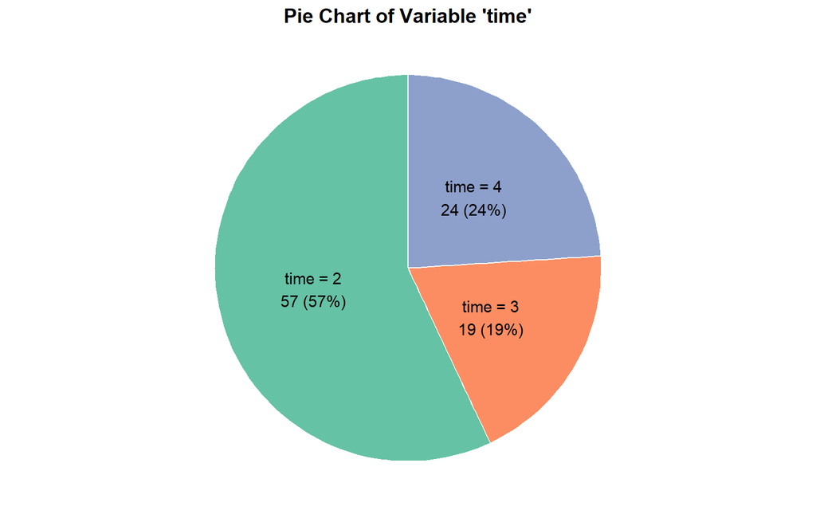

```r
freq_time_df_gg <- freq_time_df_gg %>%
  mutate(pct = count / sum(count),
         label = paste0("time = ", time, "\n", count, " (", scales::percent(pct, accuracy = 1), ")"))

ggplot(freq_time_df_gg, aes(x = "", y = count, fill = time)) +
  geom_col(width = 1, color = "white") +
  coord_polar(theta = "y") +
  geom_text(aes(label = label), position = position_stack(vjust = 0.5), size = 4) +
  scale_fill_brewer(palette = "Set2") +
  labs(title = "Pie Chart of Variable 'time'", fill = "Time Category") +
  theme_void() +
  theme(plot.title = element_text(face = "bold", hjust = 0.5, size = 14),
        legend.position = "none")
```

## 8 Άσκηση 6: Διερεύνηση σχέσης μεταξύ ποσοτικών μεταβλητών

```r
cor_matrix <- cor(numeric_data)

kable(cor_matrix,
      digits = 3,
      caption = "Πίνακας Συσχέτισης") %>%
  kable_styling(full_width = FALSE, position = "center")
```

Πίνακας Συσχέτισης

|  | Followers | Hours.since.posted | Likes |
| --- | --- | --- | --- |
| Followers | 1.000 | 0.251 | 0.266 |
| Hours.since.posted | 0.251 | 1.000 | 0.610 |
| Likes | 0.266 | 0.610 | 1.000 |

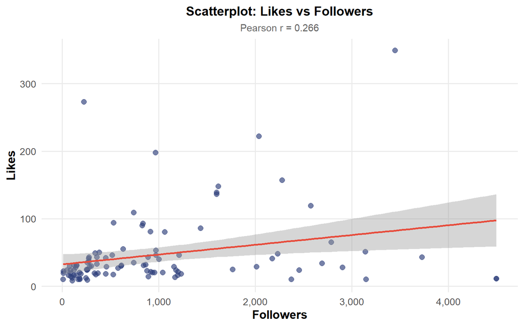

```r
ggplot(instagram_reach, aes(x = Followers, y = Likes)) +
  geom_point(color = "#2C3E7A", alpha = 0.65, size = 2.5) +
  geom_smooth(method = "lm", se = TRUE, color = "#E74C3C", linewidth = 1) +
  labs(title = "Scatterplot: Likes vs Followers",
       subtitle = paste0("Pearson r = ", round(cor(instagram_reach$Followers, instagram_reach$Likes), 3)),
       x = "Followers", y = "Likes") +
  scale_x_continuous(labels = scales::comma) +
  theme_report()
```

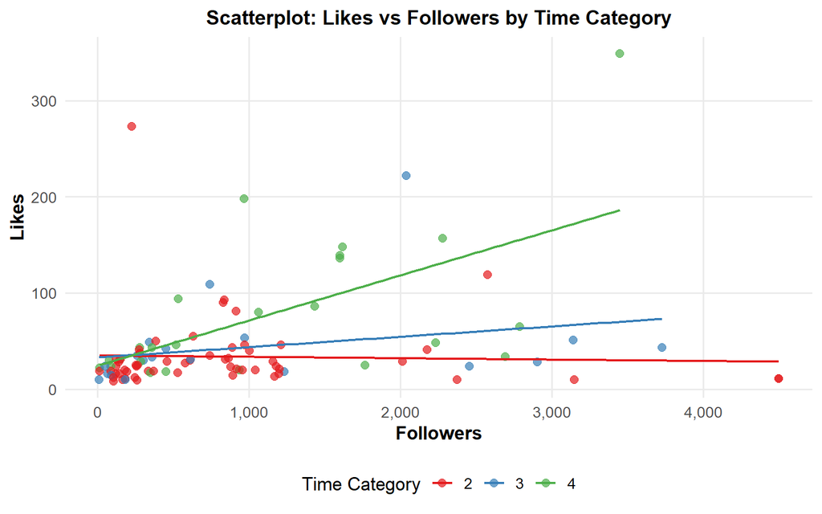

```r
ggplot(instagram_reach, aes(x = Followers, y = Likes, color = time)) +
  geom_point(alpha = 0.7, size = 2.5) +
  geom_smooth(method = "lm", se = FALSE, linewidth = 0.8) +
  scale_color_brewer(palette = "Set1") +
  labs(title = "Scatterplot: Likes vs Followers by Time Category",
       x = "Followers", y = "Likes", color = "Time Category") +
  scale_x_continuous(labels = scales::comma) +
  theme_report()
```

## 9 Άσκηση 7: Σχέση μεταξύ ποσοτικής και κατηγορικής μεταβλητής

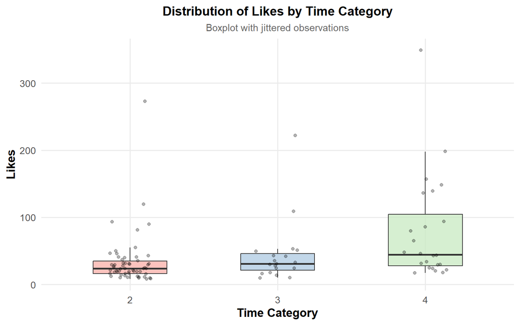

```r
ggplot(instagram_reach, aes(x = time, y = Likes, fill = time)) +
  geom_boxplot(alpha = 0.8, outlier.shape = NA, width = 0.5) +
  geom_jitter(width = 0.15, alpha = 0.3, size = 1.5) +
  scale_fill_brewer(palette = "Pastel1") +
  labs(title = "Distribution of Likes by Time Category",
       subtitle = "Boxplot with jittered observations",
       x = "Time Category", y = "Likes") +
  theme_report() +
  theme(legend.position = "none")
```

## 10 Άσκηση 8: Σχέση μεταξύ κατηγορικών μεταβλητών

```r
cont_table <- table(instagram_reach$time, instagram_reach$like)

cont_df <- as.data.frame.matrix(cont_table)
cont_df$time <- rownames(cont_df)
rownames(cont_df) <- NULL
cont_df <- cont_df[, c("time", "1", "2", "3")]

kable(cont_df,
      col.names = c("time", "like=1", "like=2", "like=3"),
      caption = "Πίνακας συνάφειας μεταξύ time και like") %>%
  kable_styling(full_width = FALSE, position = "center")
```

Πίνακας συνάφειας μεταξύ time και like

| time | like=1 | like=2 | like=3 |
| --- | --- | --- | --- |
| 2 | 17 | 33 | 7 |
| 3 | 5 | 9 | 5 |
| 4 | 2 | 11 | 11 |

```r
prop_df <- as.data.frame.matrix(prop.table(cont_table, 1))
prop_df$time <- rownames(prop_df)
rownames(prop_df) <- NULL
prop_df <- prop_df[, c("time", "1", "2", "3")]

kable(prop_df,
      col.names = c("time", "like=1", "like=2", "like=3"),
      digits = 2,
      caption = "Σχετικές συχνότητες (ανά time)") %>%
  kable_styling(full_width = FALSE, position = "center")
```

Σχετικές συχνότητες (ανά time)

| time | like=1 | like=2 | like=3 |
| --- | --- | --- | --- |
| 2 | 0.30 | 0.58 | 0.12 |
| 3 | 0.26 | 0.47 | 0.26 |
| 4 | 0.08 | 0.46 | 0.46 |

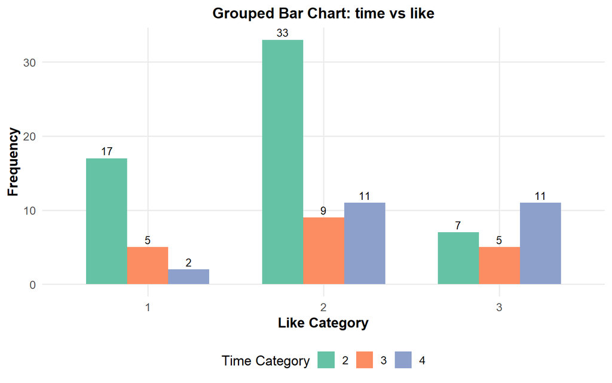

```r
cont_df_long <- as.data.frame(cont_table)
colnames(cont_df_long) <- c("time", "like", "count")

ggplot(cont_df_long, aes(x = like, y = count, fill = time)) +
  geom_col(position = "dodge", width = 0.7) +
  scale_fill_brewer(palette = "Set2") +
  geom_text(aes(label = count), position = position_dodge(width = 0.7),
            vjust = -0.4, size = 3.5) +
  labs(title = "Grouped Bar Chart: time vs like",
       x = "Like Category", y = "Frequency", fill = "Time Category") +
  theme_report()
```

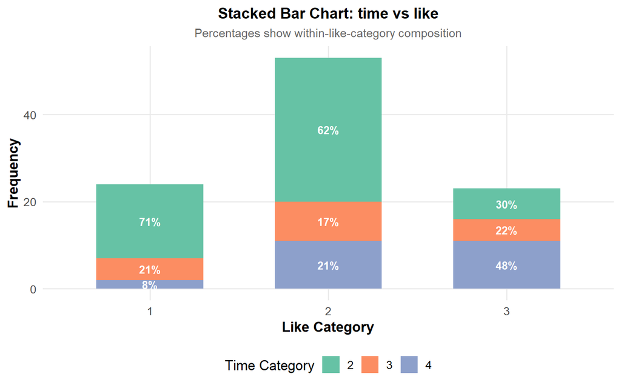

```r
cont_df_long <- cont_df_long %>%
  group_by(like) %>%
  mutate(pct = count / sum(count))

ggplot(cont_df_long, aes(x = like, y = count, fill = time)) +
  geom_col(position = "stack", width = 0.6) +
  geom_text(aes(label = scales::percent(pct, accuracy = 1)),
            position = position_stack(vjust = 0.5), size = 3.5, color = "white", fontface = "bold") +
  scale_fill_brewer(palette = "Set2") +
  labs(title = "Stacked Bar Chart: time vs like",
       subtitle = "Percentages show within-like-category composition",
       x = "Like Category", y = "Frequency", fill = "Time Category") +
  theme_report()
```

## 11 Άσκηση 9: Δημιουργία μεταβλητής υψηλής αλληλεπίδρασης

```r
instagram_reach$high_like <- ifelse(instagram_reach$like == 3, 1, 0)
instagram_reach$high_like <- factor(
  instagram_reach$high_like,
  levels = c(0, 1),
  labels = c("Low/Medium Engagement", "High Engagement")
)

high_like_freq <- as.data.frame(table(instagram_reach$high_like))
colnames(high_like_freq) <- c("high_like", "Frequency")

high_like_prop <- data.frame(
  high_like = names(prop.table(table(instagram_reach$high_like))),
  Relative_Frequency = as.numeric(prop.table(table(instagram_reach$high_like)))
)

kable(high_like_freq,
      col.names = c("high_like", "Συχνότητα"),
      caption = "Κατανομή της μεταβλητής high_like") %>%
  kable_styling(full_width = FALSE, position = "center")
```

Κατανομή της μεταβλητής high_like

| high_like | Συχνότητα |
| --- | --- |
| Low/Medium Engagement | 77 |
| High Engagement | 23 |

```r
kable(high_like_prop,
      digits = 2,
      col.names = c("high_like", "Σχετική Συχνότητα"),
      caption = "Σχετικές συχνότητες της μεταβλητής high_like") %>%
  kable_styling(full_width = FALSE, position = "center")
```

Σχετικές συχνότητες της μεταβλητής high_like

| high_like | Σχετική Συχνότητα |
| --- | --- |
| Low/Medium Engagement | 0.77 |
| High Engagement | 0.23 |

## 12 Άσκηση 10: Μοντέλο Λογιστικής Παλινδρόμησης

```r
model_logit <- glm(high_like ~ Followers + Hours.since.posted,
                   data = instagram_reach,
                   family = binomial)

predicted_prob <- predict(model_logit, type = "response")
predicted_class <- ifelse(predicted_prob > 0.5, 1, 0)

cm <- table(
  Predicted = predicted_class,
  Actual = instagram_reach$high_like
)

accuracy <- mean(predicted_class == as.numeric(instagram_reach$high_like) - 1)

coef_table <- as.data.frame(summary(model_logit)$coefficients)
coef_table$Variable <- rownames(coef_table)
rownames(coef_table) <- NULL
coef_table <- coef_table[, c("Variable", "Estimate", "Std. Error", "z value", "Pr(>|z|)")]

kable(coef_table,
      digits = 4,
      col.names = c("Variable", "Estimate", "Std. Error", "z value", "p-value"),
      caption = "Logistic Regression Coefficients") %>%
  kable_styling(full_width = FALSE, position = "center")
```

Logistic Regression Coefficients

| Variable | Estimate | Std. Error | z value | p-value |
| --- | --- | --- | --- | --- |
| (Intercept) | -3.3619 | 0.6487 | -5.1827 | 0.0000 |
| Followers | 0.0004 | 0.0002 | 1.7750 | 0.0759 |
| Hours.since.posted | 0.4859 | 0.1571 | 3.0925 | 0.0020 |

```r
kable(cm,
      caption = "Confusion Matrix") %>%
  kable_styling(full_width = FALSE, position = "center")
```

Confusion Matrix

|  | Low/Medium Engagement | High Engagement |
| --- | --- | --- |
| 0 | 75 | 15 |
| 1 | 2 | 8 |

```r
cat("**Model Accuracy:**", round(accuracy * 100, 2), "%")
```

```
## **Model Accuracy:** 83 %
```

```r
# --- Precision, Recall, F1 ---
tp <- cm["1", "High Engagement"]
fp <- cm["1", "Low/Medium Engagement"]
fn <- cm["0", "High Engagement"]

precision <- tp / (tp + fp)
recall    <- tp / (tp + fn)
f1        <- 2 * precision * recall / (precision + recall)

metrics_df <- data.frame(
  Metric = c("Accuracy", "Precision", "Recall (Sensitivity)", "F1-Score"),
  Value  = round(c(accuracy, precision, recall, f1), 4)
)

kable(metrics_df,
      caption = "Model Performance Metrics",
      col.names = c("Metric", "Value")) %>%
  kable_styling(full_width = FALSE, position = "center") %>%
  row_spec(0, bold = TRUE)
```

Model Performance Metrics

| Metric | Value |
| --- | --- |
| Accuracy | 0.8300 |
| Precision | 0.8000 |
| Recall (Sensitivity) | 0.3478 |
| F1-Score | 0.4848 |

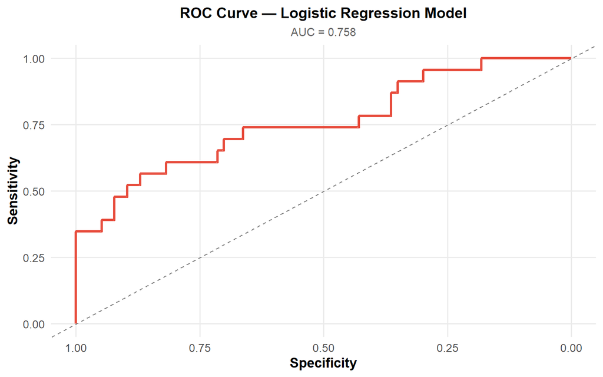

```r
roc_obj <- roc(
  response  = as.numeric(instagram_reach$high_like) - 1,
  predictor = predicted_prob,
  quiet     = TRUE
)

ggroc(roc_obj, color = "#E74C3C", linewidth = 1.2) +
  geom_abline(slope = 1, intercept = 1, linetype = "dashed", color = "grey50") +
  labs(title = "ROC Curve — Logistic Regression Model",
       subtitle = paste0("AUC = ", round(auc(roc_obj), 3)),
       x = "Specificity", y = "Sensitivity") +
  theme_report()
```

Η μεταβλητή `Hours.since.posted` παρουσιάζει στατιστικά σημαντική θετική επίδραση (p < 0.01): όσο αυξάνεται ο χρόνος από τη δημοσίευση, τόσο αυξάνεται και η πιθανότητα μια ανάρτηση να ταξινομηθεί ως υψηλής αλληλεπίδρασης. Αντίθετα, η επίδραση των `Followers` παραμένει πιο ήπια.

Η συνολική ακρίβεια του μοντέλου είναι **0.83** (ή περίπου **83%**), επομένως η ταξινόμηση είναι ικανοποιητική αλλά όχι επαρκής από μόνη της για πλήρη αξιολόγηση.

Το AUC ερμηνεύεται ως η πιθανότητα το μοντέλο να δώσει υψηλότερο σκορ σε ένα πραγματικά high-engagement post σε σχέση με ένα low/medium post. Επειδή το dataset είναι ανισόρροπο (περίπου 77% Low/Medium έναντι 23% High), η ακρίβεια μπορεί να υπερεκτιμήσει την πραγματική απόδοση· για αυτό εξετάζονται συμπληρωματικά και οι δείκτες AUC και F1-Score.

## 14 Appendix: Reproducibility

```r
sessionInfo()
## R version 4.4.2 (2024-10-31 ucrt)
## Platform: x86_64-w64-mingw32/x64
## Running under: Windows 11 x64 (build 26200)
##
## Matrix products: default
##
##
## locale:
## [1] LC_COLLATE=Greek_Greece.utf8  LC_CTYPE=Greek_Greece.utf8
## [3] LC_MONETARY=Greek_Greece.utf8 LC_NUMERIC=C
## [5] LC_TIME=Greek_Greece.utf8
##
## time zone: Europe/Athens
## tzcode source: internal
##
## attached base packages:
## [1] stats     graphics  grDevices utils     datasets  methods   base
##
## other attached packages:
## [1] pROC_1.19.0.1    scales_1.3.0     dplyr_1.1.4      ggplot2_3.5.1
## [5] kableExtra_1.4.0 knitr_1.51
##
## loaded via a namespace (and not attached):
##  [1] Matrix_1.7-1       gtable_0.3.6       jsonlite_2.0.0     compiler_4.4.2
##  [5] Rcpp_1.1.1         tidyselect_1.2.1   xml2_1.5.2         stringr_1.6.0
##  [9] jquerylib_0.1.4    splines_4.4.2      systemfonts_1.3.2  textshaping_1.0.5
## [13] yaml_2.3.12        fastmap_1.2.0      lattice_0.22-6     R6_2.5.1
## [17] labeling_0.4.3     generics_0.1.3     tibble_3.2.1       munsell_0.5.1
## [21] svglite_2.2.2      RColorBrewer_1.1-3 bslib_0.10.0       pillar_1.9.0
## [25] rlang_1.1.4        utf8_1.2.4         cachem_1.1.0       stringi_1.8.7
## [29] xfun_0.56          sass_0.4.10        viridisLite_0.4.2  cli_3.6.3
## [33] mgcv_1.9-1         withr_3.0.2        magrittr_2.0.3     digest_0.6.39
## [37] grid_4.4.2         rstudioapi_0.18.0  nlme_3.1-166       lifecycle_1.0.4
## [41] vctrs_0.6.5        evaluate_1.0.5     glue_1.8.0         farver_2.1.2
## [45] fansi_1.0.6        colorspace_2.1-1   rmarkdown_2.30     tools_4.4.2
## [49] pkgconfig_2.0.3    htmltools_0.5.9
```